# DƏRS 1: Qiymətləndirmə Nəzəriyyəsinin Əsasları və R-də Praktiki Tətbiqi

İmtahan İşlərinin və Esse Yazılarının Elmi Əsaslarla Qiymətləndirilməsi

Azərbaycan Respublikası Təhsil Nazirliyi - Peşəkar İnkişaf Mərkəzi

2025-07-31

### 🎯 DƏRSİN ÖYRƏNMƏ MƏQSƏDLƏRİ

Bu dərsin sonunda siz aşağıdakıları bacara biləcəksiniz:

- **Nəzəri bilik:** Müasir qiymətləndirmə nəzəriyyəsinin əsas prinsiplərini izah etmək
- **Analitik bacarıq:** Validlik və etibarlılıq meyarlarını tətbiq etmək
- **Müqayisəli təhlil:** Dünya ölkələrinin qiymətləndirmə təcrübələrini analiz etmək
- **Praktiki tətbiq:** R proqram dilində qiymətləndirmə sistemlərini modelləşdirmək
- **Kontekstual adaptasiya:** Azərbaycan təhsil sistemi üçün təkliflər hazırlamaq

# 1 Qiymətləndirmə Nəzəriyyəsinin Tarixi və İnkişafı

Təhsildə qiymətləndirmə tarixi insanlığın öyrənmə fəaliyyətinin özü qədər qədimdir. Müasir qiymətləndirmə nəzəriyyəsinin formalaşması bir neçə mərhalədən keçmişdir:

#### 📚 Tarixi Mərhələlər

- **Qədim dövr (e.ə. 2000-500):** Çin imperiyasında dövlət qulluqçularının seçimi üçün imtahanlar
- **Orta əsrlər:** Universitetlərdə disputasiya və müdafiə ənənəsi
- **19-cu əsr:** Standartlaşdırılmış testlərin yaranması
- **20-ci əsr əvvəli:** Psixometrik metodların inkişafı
- **Müasir dövr:** Formativ qiymətləndirmə və çoxölçülü yanaşmalar

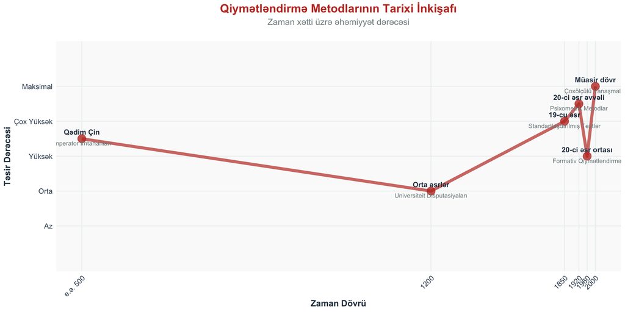

```r
# Qiymətləndirmə tarixinin vizual təqdimatı
timeline_data <- tibble(
  period = c("Qədim Çin", "Orta əsrlər", "19-cu əsr", "20-ci əsr əvvəli", "20-ci əsr ortası", "Müasir dövr"),
  year = c(-500, 1200, 1850, 1920, 1960, 2000),
  innovation = c("İmperator İmtahanları", "Universiteit Disputasiyaları",
                 "Standartlaşdırılmış Testlər", "Psixometrik Metodlar",
                 "Formativ Qiymətləndirmə", "Çoxölçülü Yanaşmalar"),
  importance = c(85, 70, 90, 95, 80, 100)
)

timeline_data %>%
  ggplot(aes(x = year, y = importance)) +
  geom_line(color = "#c0392b", size = 2, alpha = 0.7) +
  geom_point(color = "#c0392b", size = 5, alpha = 0.8) +
  geom_text(aes(label = period),
            hjust = 0.5, vjust = -0.8, size = 3.5, fontface = "bold", color = "#2c3e50") +
  geom_text(aes(label = innovation),
            hjust = 0.5, vjust = 1.5, size = 3, color = "#7f8c8d") +
  scale_x_continuous(breaks = timeline_data$year,
                     labels = c("e.ə. 500", "1200", "1850", "1920", "1960", "2000")) +
  scale_y_continuous(limits = c(50, 110),
                     breaks = c(60, 70, 80, 90, 100),
                     labels = c("Az", "Orta", "Yüksək", "Çox Yüksək", "Maksimal")) +
  labs(title = "Qiymətləndirmə Metodlarının Tarixi İnkişafı",
       subtitle = "Zaman xətti üzrə əhəmiyyət dərəcəsi",
       x = "Zaman Dövrü",
       y = "Təsir Dərəcəsi") +
  theme_azerbaijan_education() +
  theme(axis.text.x = element_text(angle = 45, hjust = 1))
```

```r
cat("📊 TARİXİ İNKİŞAF STATİSTİKALARI:\n")
```

```
#> 📊 TARİXİ İNKİŞAF STATİSTİKALARI:
```

```r
cat("==============================\n")
cat("📅 Əhatə olunan dövr:", max(timeline_data$year) - min(timeline_data$year), "il\n")
```

```
#> 📅 Əhatə olunan dövr: 2500 il
```

```r
cat("🎯 Orta təsir dərəcəsi:", round(mean(timeline_data$importance), 1), "\n")
```

```
#> 🎯 Orta təsir dərəcəsi: 86.7
```

```r
cat("📈 Ən yüksək təsir dövrü:", timeline_data$period[which.max(timeline_data$importance)], "\n")
```

```
#> 📈 Ən yüksək təsir dövrü: Müasir dövr
```

# 2 Müasir Qiymətləndirmə Nəzəriyyəsinin Əsas Prinsipləri

#### 💡 QİYMƏTLƏNDİRMƏ (Assessment) - Nədir?

**Təhsildə qiymətləndirmə** - tələbələrin öyrənmə nəticələrinin, bilik və bacarıqlarının sistematik şəkildə ölçülməsi, təhlil edilməsi və qiymətləndirilməsi prosesidir.

**Əsas komponentlər:**

- 📊 **Ölçmə (Measurement):** Kəmiyyət göstəriciləri
- 🔍 **Təhlil (Analysis):** Məlumatların işlənməsi
- ⚖️ **Qiymətləndirmə (Evaluation):** Keyfiyyət mühakimələri
- 📈 **Qərar qəbulu (Decision Making):** Praktiki nəticələr

## 2.1 R-də Qiymətləndirmə Sisteminin Modelləşdirilməsi

```r
# Qiymətləndirmə sistemi üçün nümunə məlumatların yaradılması
set.seed(2024)

# Tələbə bazası - Azərbaycan məktəbi üçün real profil
students_profile <- tibble(
  student_id = 1:120,
  name = paste("Tələbə", str_pad(1:120, 3, pad = "0")),
  class = sample(c("9A", "9B", "10A", "10B", "11A", "11B"), 120, replace = TRUE),
  gender = sample(c("Qız", "Oğlan"), 120, replace = TRUE, prob = c(0.51, 0.49)),
  birth_year = sample(2006:2009, 120, replace = TRUE),
  region = sample(c("Bakı", "Gəncə", "Sumqayıt", "Şəki", "Quba", "Lənkəran", "Naxçıvan"),
                  120, replace = TRUE,
                  prob = c(0.30, 0.15, 0.12, 0.10, 0.10, 0.13, 0.10)),
  ses_level = sample(c("Aşağı", "Orta", "Yüksək"), 120, replace = TRUE,
                     prob = c(0.20, 0.65, 0.15))
) %>%
  mutate(
    age = 2024 - birth_year,
    grade_level = as.numeric(str_extract(class, "\\d+"))
  )

# İlk baxış - məlumatların strukturu
cat("📊 Təhsil Qiymətləndirmə Sisteminin Komponenətləri\n")
```

```
#> 📊 Təhsil Qiymətləndirmə Sisteminin Komponenətləri
```

```r
cat("==================================================\n\n")
cat("👥 Tələbə sayı:", nrow(students_profile), "tələbə\n")
```

```
#> 👥 Tələbə sayı: 120 tələbə
```

```r
cat("🏫 Sinif sayı:", length(unique(students_profile$class)), "sinif\n")
```

```
#> 🏫 Sinif sayı: 6 sinif
```

```r
cat("🌍 Region sayı:", length(unique(students_profile$region)), "region\n")
```

```
#> 🌍 Region sayı: 7 region
```

```r
cat("👨‍👩‍👧‍👦 Orta yaş:", round(mean(students_profile$age), 1), "yaş\n")
```

```
#> 👨‍👩‍👧‍👦 Orta yaş: 16.4 yaş
```

```r
# Məlumatların nümunəsi
head(students_profile, 8) %>%
  kable(caption = "Tələbə Profili Məlumatları (İlk 8 tələbə)") %>%
  kable_styling(bootstrap_options = c("striped", "hover"))
```

Tələbə Profili Məlumatları (İlk 8 tələbə)

| student_id | name | class | gender | birth_year | region | ses_level | age | grade_level |
| --- | --- | --- | --- | --- | --- | --- | --- | --- |
| 1 | Tələbə 001 | 9B | Oğlan | 2006 | Quba | Orta | 18 | 9 |
| 2 | Tələbə 002 | 11A | Qız | 2006 | Sumqayıt | Orta | 18 | 11 |
| 3 | Tələbə 003 | 11A | Oğlan | 2008 | Şəki | Orta | 16 | 11 |
| 4 | Tələbə 004 | 10B | Qız | 2009 | Gəncə | Yüksək | 15 | 10 |
| 5 | Tələbə 005 | 9A | Qız | 2007 | Naxçıvan | Orta | 17 | 9 |
| 6 | Tələbə 006 | 11A | Qız | 2009 | Bakı | Orta | 15 | 11 |
| 7 | Tələbə 007 | 9A | Oğlan | 2009 | Quba | Orta | 15 | 9 |
| 8 | Tələbə 008 | 9B | Qız | 2006 | Bakı | Aşağı | 18 | 9 |

**✅ Məlumat Modeli Hazırdır!** Biz Azərbaycan təhsil kontekstinə uyğun 120 tələbə üçün qiymətləndirmə məlumatları yaratdıq. Bu model real məktəb şəraitindəki tələbə müxtəlifliyini və demografik paylanmanı əks etdirir.

## 2.2 Formativ vs Summativ Qiymətləndirmə

#### 🔍 Formativ və Summativ Qiymətləndirmənin Müqayisəsi

**Formativ Qiymətləndirmə (Assessment FOR Learning)**

- Öyrənmə prosesi zamanı aparılır
- Tələbələrin inkişafını izləyir
- Dərhal əks əlaqə verir
- Tədrisi təkmilləşdirir

**Summativ Qiymətləndirmə (Assessment OF Learning)**

- Öyrənmə prosesinin sonunda aparılır
- Nəticələri ölçür və qiymətləndirir
- Rəsmi qiymət və sertifikatlaşdırma
- Hesabatlılıq və müqayisə məqsədilə istifadə olunur

```r
# Formativ və summativ qiymətləndirmənin müqayisəsi
assessment_types <- tibble(
  Type = rep(c("Formativ", "Summativ"), each = 6),
  Characteristic = rep(c("Tezlik", "Məqsəd", "Əks əlaqə", "İstifadə", "Stress", "Məlumat"), 2),
  Score = c(95, 90, 95, 85, 20, 80,  # Formativ
            30, 85, 40, 95, 80, 90), # Summativ
  Description = c("Davamlı", "İnkişaf dəstəyi", "Dərhal", "Tədrisi yaxşılaşdırmaq", "Az", "Proses",
                  "Nadir", "Nəticə ölçmə", "Gecikmiş", "Qiymətləndirmə", "Yüksək", "Nəticə")
)

comparison_plot <- assessment_types
```